# HW4

DACSS-603

Katie Popiela  
4/25/2022

# Question 1

*(SMSS 14.3, 14.4, merged and modified); data file house.selling.price.2*

```r
library(smss)
data(house.selling.price.2)
names(house.selling.price.2) <- c('Price','Size','Bedrooms','Bathrooms','New')

summary(house.selling.price.2)
```

```
     Price             Size         Bedrooms       Bathrooms
 Min.   : 17.50   Min.   :0.40   Min.   :1.000   Min.   :1.000
 1st Qu.: 72.90   1st Qu.:1.33   1st Qu.:3.000   1st Qu.:2.000
 Median : 96.00   Median :1.57   Median :3.000   Median :2.000
 Mean   : 99.53   Mean   :1.65   Mean   :3.183   Mean   :1.957
 3rd Qu.:115.00   3rd Qu.:1.98   3rd Qu.:4.000   3rd Qu.:2.000
 Max.   :309.40   Max.   :3.85   Max.   :5.000   Max.   :3.000
      New
 Min.   :0.0000
 1st Qu.:0.0000
 Median :0.0000
 Mean   :0.3011
 3rd Qu.:1.0000
 Max.   :1.0000
```

**a.** For backward elimination, ‘Bedrooms’ would be deleted first because it’s p-value is the highest at 0.487.

**b.** For forward selection, ‘Size’ would be added first as it has a p-value of 0.

**c.** ‘Bedrooms’ may have such a large p-value in the multiple regression model due to its correlation with ‘Size’. A house can (and most often does) sell for more as the number of bedrooms (and therefore house size) increases.

**d.** According to the book (p. 420-423), backward elimination, forward selection, and stepwise regression point to one model: the one that excludes the variable ‘Bedrooms’. To confirm these findings, I’m going to compare the model without ‘Bedrooms’ to one that does.

```r
fit_bedrooms <- lm(Price~.,data=house.selling.price.2)
fit_no_bedrooms <- lm(Price~.-Bedrooms,data=house.selling.price.2)
```

Part of this process is to write functions to gather the specific information we’re looking for.

```r
rsq <- function(fit)+
  summary(fit)$r.squared
adj_rsq <- function(fit)+
  summary(fit)$adj.r.squared
press <- function(fit) {
  pr <- residuals(fit)/(1-lm.influence(fit)$hat)
  sum(pr^2)
}
```

Ant then we apply them to the model including ‘Bedrooms’ and the one which does not.

```r
beds_models <- list(fit_bedrooms, fit_no_bedrooms)
data.frame(beds_models = c('fit_bedrooms','fit_no_bedrooms'),
           rsq=sapply(beds_models,rsq),
           adj_rsq=sapply(beds_models, adj_rsq),
           press=sapply(beds_models,press),
           AIC=sapply(beds_models, AIC),
           BIC=sapply(beds_models,BIC)
)
```

```
      beds_models       rsq   adj_rsq    press      AIC      BIC
1    fit_bedrooms 0.8688630 0.8629022 28390.22 790.6225 805.8181
2 fit_no_bedrooms 0.8681361 0.8636912 27860.05 789.1366 801.7996
```

For R^2 and Adjusted R^2, the larger the figure the ‘better’; for Press, AIC, and BIC, the opposite applies. The model that excludes ‘Bedrooms’ is ‘better’ as it has a higher Adjusted R^2 and lower Press, AIC, and BIC.

**e.** Based on the model comparison above, I select the model without the variable ‘Bedrooms’.

# Question 2

*(Data file ‘trees’ from base R)*

**From the documentation:**  
**“This data set provides measurements of the diameter, height and volume of timber in 31 felled black cherry trees. Note that the diameter (in inches) is erroneously labelled Girth in the data. It is measured at 4 ft 6 in above the ground.”**

**Tree volume estimation is a big deal, especially in the lumber industry. Use the trees data to build a basic model of tree volume prediction. In particular,**  
**a. fit a multiple regression model with ‘Volume’ as the outcome variable, and ‘Girth’ and ‘Height’ as explanatory variables**  
**b. run regression diagnostic plots on the above model. Based on the plots, do you think any regression assumptions is violated?**

```r
data(trees)
```

### a.

```r
trees_model<-lm(Volume~Girth+Height,data=trees)
summary(trees_model)
```

```
Call:
lm(formula = Volume ~ Girth + Height, data = trees)

Residuals:
    Min      1Q  Median      3Q     Max
-6.4065 -2.6493 -0.2876  2.2003  8.4847

Coefficients:
            Estimate Std. Error t value Pr(>|t|)
(Intercept) -57.9877     8.6382  -6.713 2.75e-07 ***
Girth         4.7082     0.2643  17.816  < 2e-16 ***
Height        0.3393     0.1302   2.607   0.0145 *
---
Signif. codes:  0 '***' 0.001 '**' 0.01 '*' 0.05 '.' 0.1 ' ' 1

Residual standard error: 3.882 on 28 degrees of freedom
Multiple R-squared:  0.948, Adjusted R-squared:  0.9442
F-statistic:   255 on 2 and 28 DF,  p-value: < 2.2e-16
```

### b.

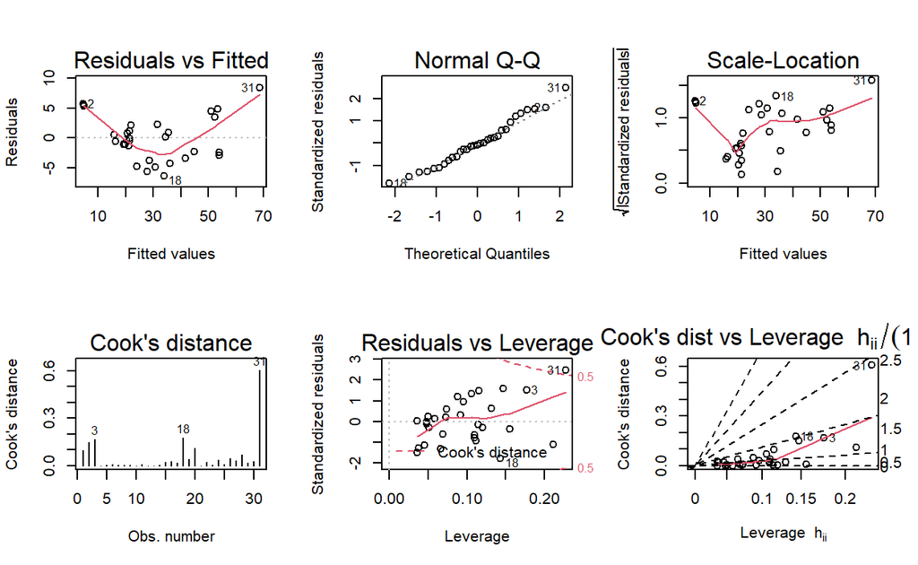

```r
par(mfrow=c(2,3))
plot(trees_model,which = 1:6)
```

Looking at the plot matrix, there are a few violations. The first plot, for instance, violates the linearity assumption as the red line is u-shaped rather than straight. This is because volume is related to diameter^2 while diameter in the model ‘Girth’.

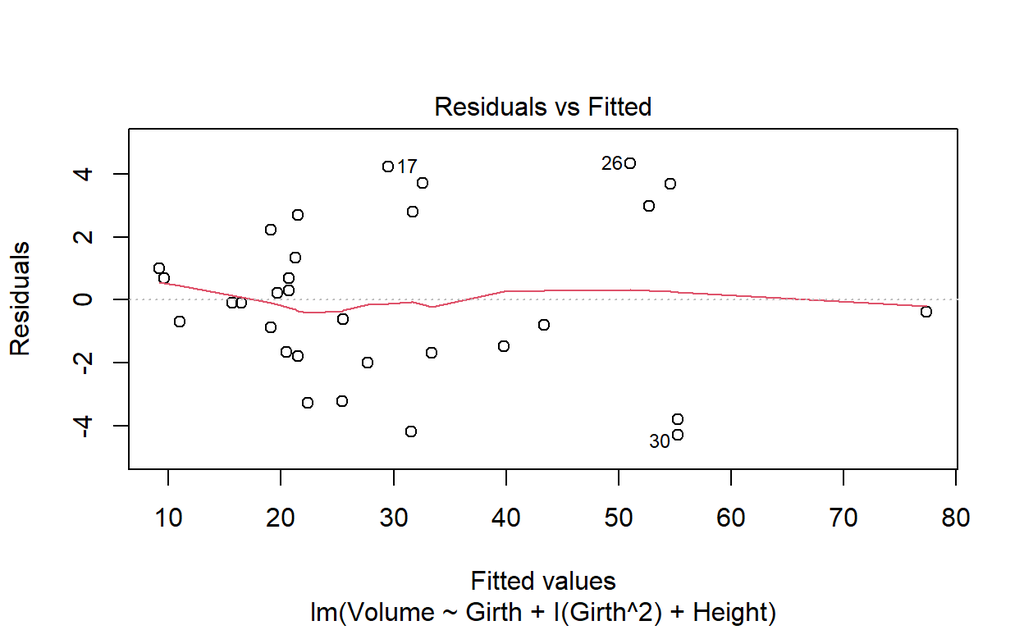

```r
trees_model_4 <- lm(Volume~Girth+I(Girth^2)+Height,data=trees)
plot(trees_model_4,which = 1)
```

As you can see, compared to the first plot in the above matrix, the red line is much more straight (and does not violate the linearity assumption).

## Question 3

*(Inspired by ALR 9.16; data file ‘florida’ in alr4 R Package)*

**In the 2000 election for U.S. president, the counting of votes in Florida was controversial. In Palm Beach County in south Florida, for example, voters used a so-called butterfly ballot. Some believe that the layout of the ballot caused some voters to cast votes for Buchanan when their intended choice was Gore.**

**The data has variables for the number of votes for each candidate—Gore, Bush, and Buchanan. Run a simple linear regression model where the Buchanan vote is the outcome and the Bush vote is the explanatory variable. Produce the regression diagnostic plots. Is Palm Beach County an outlier based on the diagnostic plots? Why or why not?**

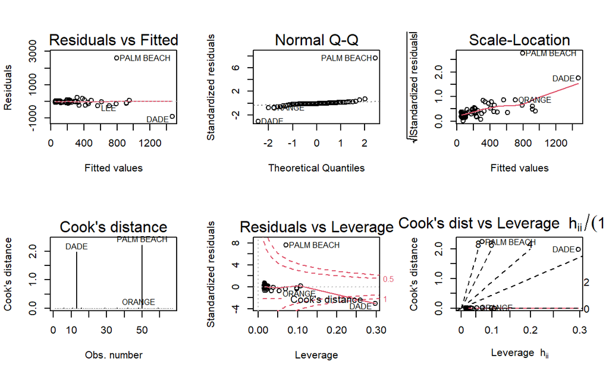

```r
library(alr4)
data(florida)
fl_voting_model <- lm(Buchanan~Bush,data=florida)
par(mfrow=c(2,3))
plot(fl_voting_model,which=1:6)
```

In this matrix, Palm Beach County is an obvious outlier. Next, I’ll see if, with a better bottle, Palm Beach County will be less of an outlier.

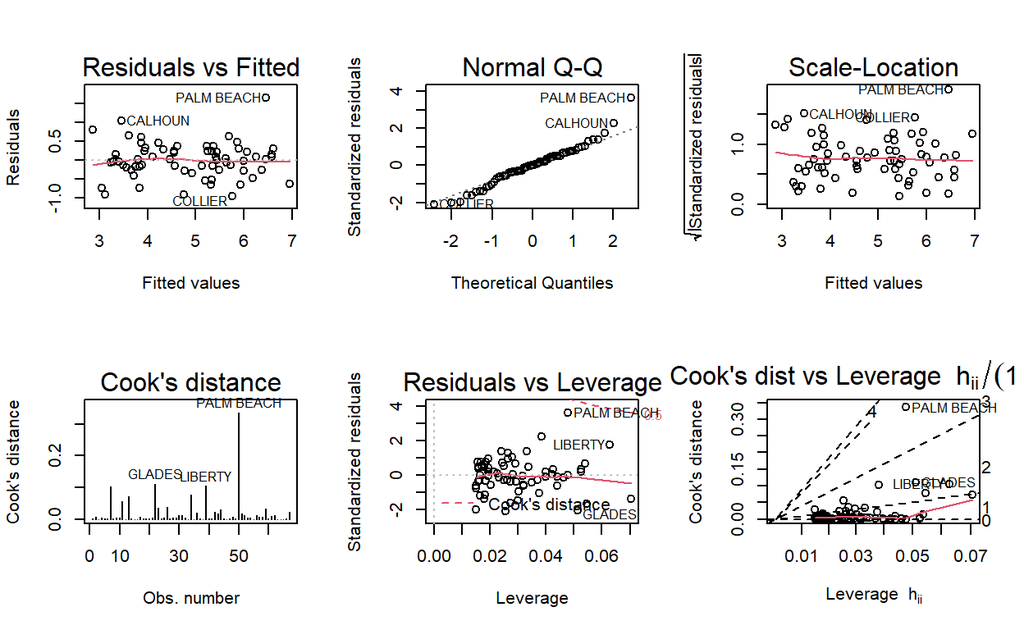

```r
data(florida)
fl_voting_model_log <- lm(log(Buchanan)~log(Bush),data=florida)
par(mfrow=c(2,3))
plot(fl_voting_model_log,which=1:6)
```

I achieved my goal of making Palm Beach County less of an outlier.

# Part 2: Final Project

**1.** For my final project I want to focus on the relationship between race and total income, and the respondents’ education level. Specifically: Does a person’s race OR education level have more of an impact on their total income? For instance, do white people with a high school diploma make more than individuals of a different race with the same or a higher degree?

**2.** The hypothesis that I want to test is as follows: in the context of racial politics in the United States (I’ll provide more info later, I need to find sources) white people generally make more than their non-white counterparts who have the same or higher-level degrees.

**3.** Below I’ll present some preliminary visualizations of my data in relation to my hypothesis.

```r
library(dplyr)
library(tidyverse)
library(poliscidata)
gss %>%
  select(race, income06, degree)%>%
  head(25) %>%
  tibble()
```

```
# A tibble: 25 x 3
   race  income06           degree
   <fct> <fct>              <fct>
 1 White $150000 OR OVER    Bachelor deg
 2 White $150000 OR OVER    HS
 3 Other $110000 TO $129999 HS
 4 White $130000 TO $149999 HS
 5 Black $50000 TO 59999    Bachelor deg
 6 White $25000 TO 29999    Bachelor deg
 7 White $30000 TO 34999    Junior Coll
 8 Other $5 000 TO 5 999    <HS
 9 Black UNDER $1 000       <HS
10 White $30000 TO 34999    Bachelor deg
# ... with 15 more rows
```

```r
race.ed.income_gss <- gss %>%
  select(race,income06,degree)
summary(race.ed.income_gss)
```

```
    race                  income06             degree
 White:1477   $60000 TO 74999 : 153   <HS         :288
 Black: 301   $40000 TO 49999 : 151   HS          :976
 Other: 196   $75000 TO $89999: 151   Junior Coll :151
              $150000 OR OVER : 144   Bachelor deg:354
              $50000 TO 59999 : 118   Graduate deg:205
              (Other)         :1041
              NA's            : 216
```

Unfortunately a heavy majority of participants in the surveys in the ‘poliscidata’ dataset are white (1477 out of 1974 total). To take this racial disparity into account, I will try to see if there is a pattern among respondents self-identifying as black or other in which a high school diploma or higher results in a lower income compared to white participants with just a high school diploma.

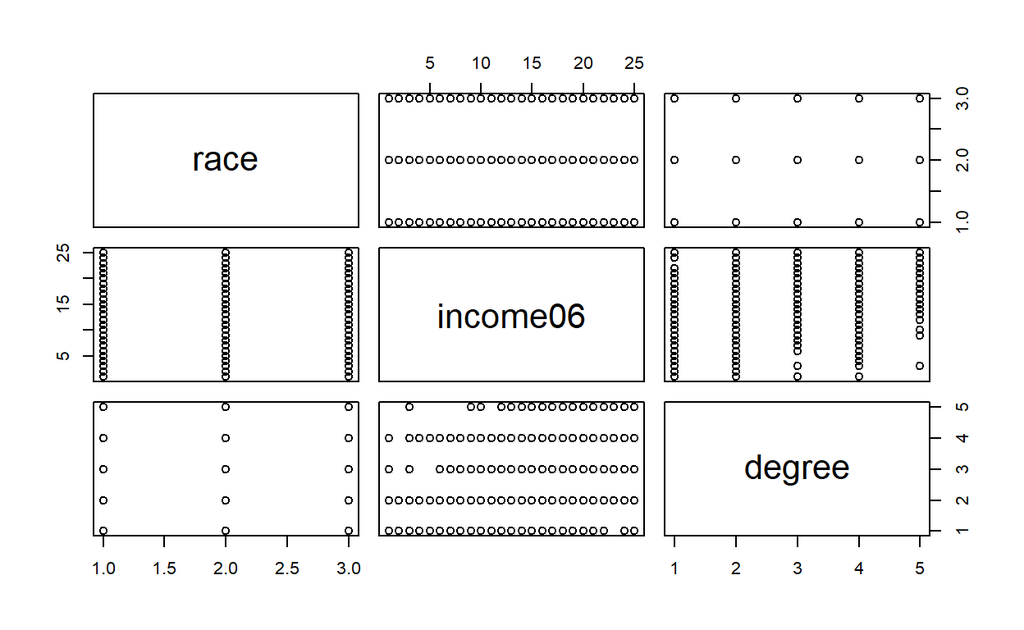

```r
pairs(race.ed.income_gss)
```

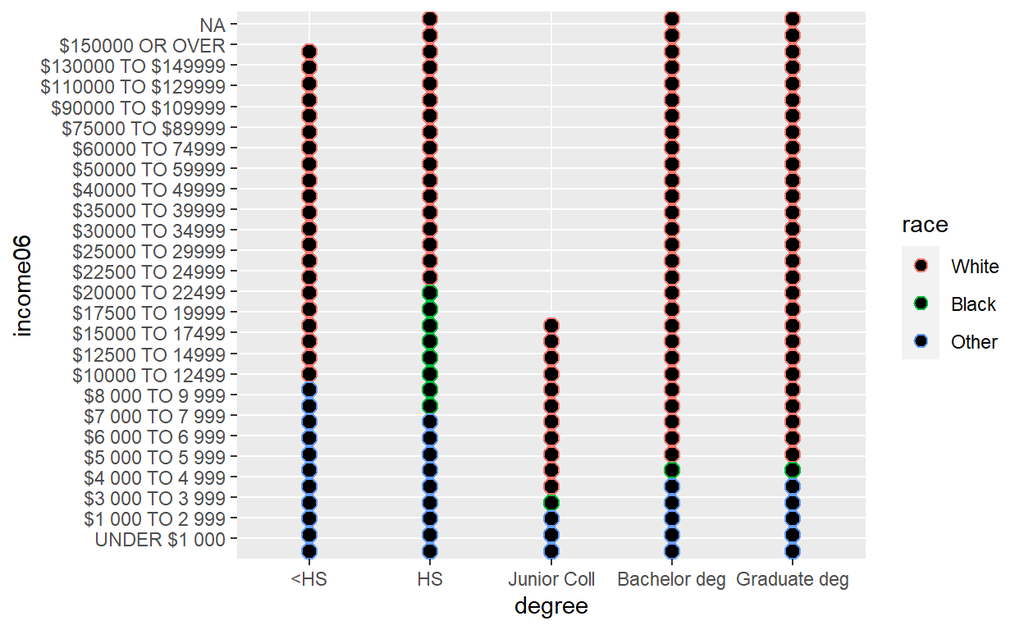

```r
library(tidyr)
library(poliscidata)
data(gss)
ggplot(data=race.ed.income_gss,mapping = aes(x=degree,y=income06))+
  geom_dotplot(aes(color=race))
```

This dot plot is the best visualization I’ve found this far, but I’m trying to figure out how to refine it a bit.